# Exploratória - IPEA

## Caracterização dos acidentes de trânsito nas rodovias federais em 2021

Em 2021 ocorreram 64.515 acidentes nas estradas federais fiscalizadas pela PRF, sendo que 5.395 pessoas perderam a vida e 71.780 ficaram feridos. Pouco mais de um quarto dos feridos teve lesões graves. Nesse ano, cerca de 7% dos acidentes apresentaram vítimas fatais; 74%, vítimas feridas; e 18% foram acidentes sem vítimas. Aproximadamente 72% dos acidentes com vítimas fatais ocorreram em zonas rurais, e 24% das mortes foram causadas por excesso de velocidade e transitar na contramão.

Tabela 1 - Quantidade de acidentes nas rodovias federais e de vítimas (2021)

| Categoria | Acidentes | Veículos envolvidos | Ilesos | Feridos | Mortos |
| --- | --- | --- | --- | --- | --- |
| Com vitimas fatais | 4663 | 8073 | 4221 | 3676 | 5395 |
| Com vitimas feridas | 48161 | 80306 | 40452 | 68104 | 0 |
| Sem vitimas | 11691 | 18318 | 18671 | 0 | 0 |
| Total | 64515 | 106697 | 63344 | 71780 | 5395 |

Tabela 2 - % de Acidentes, Veículos, Ilesos e Feridos por classificação de acidente em rodovias federais (2021)

| classificacao_acidente | Acidentes | Veículos envolvidos | Ilesos | Feridos | Mortos |
| --- | --- | --- | --- | --- | --- |
| Com vitimas fatais | 7.227777 | 7.566286 | 6.663615 | 5.121204 | 100 |
| Com vitimas feridas | 74.650856 | 75.265471 | 63.860823 | 94.878796 | 0 |
| Sem vitimas | 18.121367 | 17.168243 | 29.475562 | 0.000000 | 0 |

Tabela 3 - Uso do solo em acidentes com vítimas fatais nas rodovias federais (2021)

| uso_solo | Acidentes |
| --- | --- |
| Rural | 71.75638 |
| Urbano | 28.24362 |

Tabela 4 - Principais causas de mortes nas rodovias federais (2021)

| causa_acidente | Mortos |
| --- | --- |
| Velocidade incompativel | 12.548656 |
| Transitar na contramao | 11.807229 |
| Ausencia de reacao do condutor | 8.378128 |
| Reacao tardia ou ineficiente do condutor | 8.007414 |
| Ultrapassagem indevida | 6.635774 |
| Pedestre andava na pista | 5.764597 |
| Acessar a via sem observar a presenca dos outros veiculos | 5.616311 |
| Manobra de mudanca de faixa | 4.856349 |
| Condutor dormindo | 4.207600 |
| Ingestao de alcool pelo condutor | 4.003707 |
| Entrada inopinada do pedestre | 3.484708 |
| Pedestre cruzava a pista fora da faixa | 2.947173 |
| Condutor deixou de manter distancia do veiculo da frente | 2.075996 |
| Chuva | 1.686747 |
| Mal subito do condutor | 1.390176 |

Nesse mesmo ano, ocorreram em média 177 acidentes e houve 14 mortos por dia. Esses acidentes envolveram 106.697 veículos, uma média de 1,65 veículos por ocorrência. O estado de Minas Gerais foi o que apresentou o maior número de acidentes e mortos, enquanto o estado do Amazonas, o menor.

Tabela 5 - Indicadores médios de mortes e ocorrências por dia nas rodovias federais (2021)

| Indicador | Valor |
| --- | --- |
| media_acidentes_day | 177.239011 |
| media_mortes_day | 14.821429 |
| media_veiculos_ocorrencia | 1.653832 |

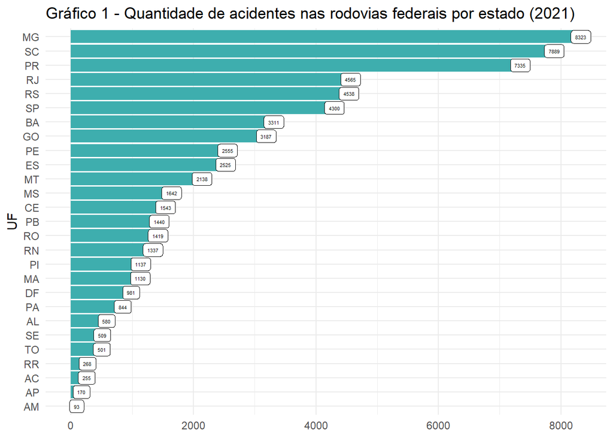

Tabela 6 - Tipo versus gravidade dos acidentes nas rodovias federais (2021)

| Tipo de Acidente | Acidentes | Feridos | Mortos | Acidentes Graves | Mortes/100 acidentes | % Acidentes |
| --- | --- | --- | --- | --- | --- | --- |
| Colisao frontal | 4345 | 6727 | 1591 | 2755 | 36.6168009 | 6.7348679 |
| Atropelamento de pedestre | 2909 | 2689 | 898 | 1258 | 30.8697147 | 4.5090289 |
| Colisao lateral sentido oposto | 1608 | 1973 | 163 | 601 | 10.1368159 | 2.4924436 |
| Eventos atipicos | 265 | 202 | 19 | 50 | 7.1698113 | 0.4107572 |
| Saida de leito carrocavel | 10650 | 12056 | 669 | 2415 | 6.2816901 | 16.5077889 |
| Colisao com objeto | 4907 | 4531 | 302 | 971 | 6.1544732 | 7.6059831 |
| Colisao transversal | 8017 | 9905 | 429 | 2829 | 5.3511289 | 12.4265675 |
| Atropelamento de animal | 978 | 1059 | 51 | 284 | 5.2147239 | 1.5159265 |
| Tombamento | 5567 | 6065 | 272 | 1167 | 4.8859350 | 8.6290010 |
| Colisao traseira | 12310 | 13435 | 579 | 2834 | 4.7034931 | 19.0808339 |
| Capotamento | 1750 | 2293 | 82 | 428 | 4.6857143 | 2.7125475 |
| Colisao lateral | 676 | 725 | 28 | 130 | 4.1420118 | 1.0478183 |
| Derramamento de carga | 156 | 63 | 6 | 19 | 3.8461538 | 0.2418042 |
| Colisao lateral mesmo sentido | 5566 | 5884 | 191 | 1152 | 3.4315487 | 8.6274510 |
| Queda de ocupante de veiculo | 2583 | 2947 | 87 | 603 | 3.3681765 | 4.0037201 |
| Engavetamento | 1054 | 1178 | 27 | 144 | 2.5616698 | 1.6337286 |
| Incendio | 1174 | 48 | 1 | 4 | 0.0851789 | 1.8197318 |

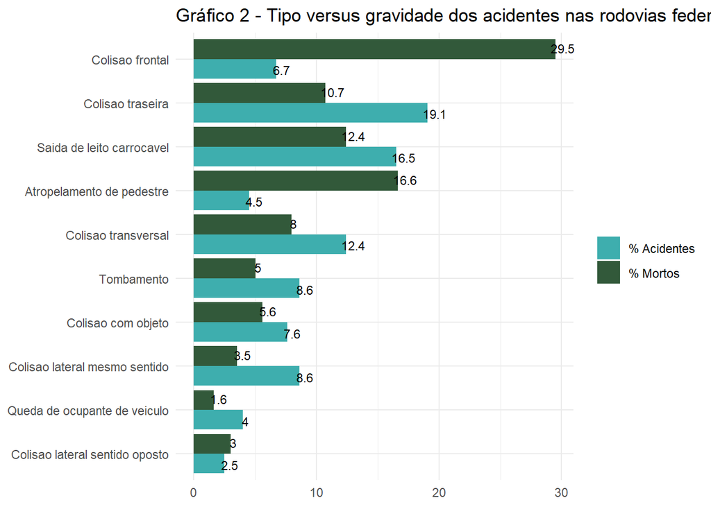

Focando os dois principais tipos de acidente que geram mais óbitos pode-se traçar um perfil dessas ocorrências: 88,88% das colisões frontais ocorreram em pistas simples, ocasionando 93,96% dos mortos nesse tipo de acidente; além disso, 70% das colisões ocorreram em trechos rurais, que ocasionou 86% dos mortos nesse tipo. Em ambos tipos de acidente, mais de 88% das ocorrências e mortes aconteceram nos períodos *plenos* - dia e noite.

Tabela 7 - Colisões frontais e atropelamentos por tipo de pista nas rodovias federais (2021)

| Tipo de acidente | Tipo de pista | % Acidentes | % Mortos |
| --- | --- | --- | --- |
| Atropelamento de pedestre | Dupla | 48.504641 | 49.888641 |
| Atropelamento de pedestre | Multipla | 11.584737 | 9.465479 |
| Atropelamento de pedestre | Simples | 39.910622 | 40.645880 |
| Colisao frontal | Dupla | 8.768700 | 4.965431 |
| Colisao frontal | Multipla | 2.347526 | 1.068510 |
| Colisao frontal | Simples | 88.883775 | 93.966059 |

Tabela 8 - Colisões frontais e atropelamentos por tipo de solo nas rodovias federais (2021)

| Tipo de acidente | Tipo de solo | % Acidentes | % Mortos |
| --- | --- | --- | --- |
| Atropelamento de pedestre | Rural | 37.98556 | 52.00445 |
| Atropelamento de pedestre | Urbano | 62.01444 | 47.99555 |
| Colisao frontal | Rural | 70.08055 | 86.04651 |
| Colisao frontal | Urbano | 29.91945 | 13.95349 |

Tabela 9 - Colisões frontais e atropelamentos por períoodo do dia nas rodovias federais (2021)

| Tipo de acidente | Fase do dia | % Acidentes | % Mortos |
| --- | --- | --- | --- |
| Atropelamento de pedestre | Amanhecer | 4.125129 | 6.458797 |
| Atropelamento de pedestre | Anoitecer | 6.668958 | 3.897550 |
| Atropelamento de pedestre | Plena noite | 55.379856 | 67.037862 |
| Atropelamento de pedestre | Pleno dia | 33.826057 | 22.605791 |
| Colisao frontal | Amanhecer | 5.523590 | 6.096794 |
| Colisao frontal | Anoitecer | 6.283084 | 5.593966 |
| Colisao frontal | Plena noite | 44.856156 | 44.123193 |
| Colisao frontal | Pleno dia | 43.337169 | 44.186047 |

Em relação aos atropelamentos, esses eventos ocorrem com bastante frequência nas rodovias federais. Em 2021 houve 2.909 acidentes com atropelamento, com 898 mortes e 1.258 feridos graves. Os estados de Paraná, Minas Gerais, São Paulo e Rio de Janeiro registraram 41% dos pedestres mortos em acidentes. Além disso, ainda nesse tipo de acidente, destaca-se:

Tabela 10 - Indicadores de quantidadem para casos de atropelamento de pessoas (2021)

| Indicador | Valor |
| --- | --- |
| qtd_acidentes | 2909 |
| qtd_mortos | 898 |
| qtd_feridos_leves | 1431 |
| qtd_feridos_graves | 1258 |

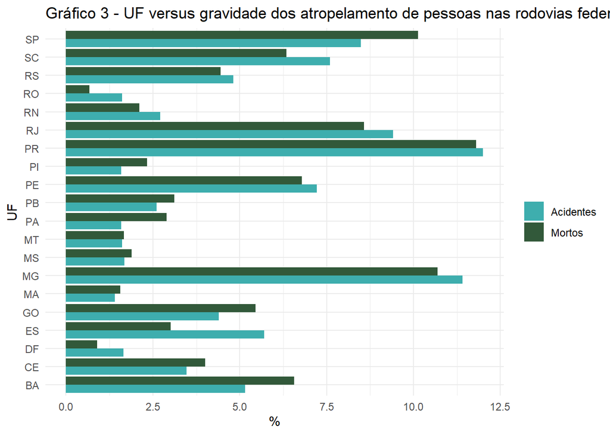

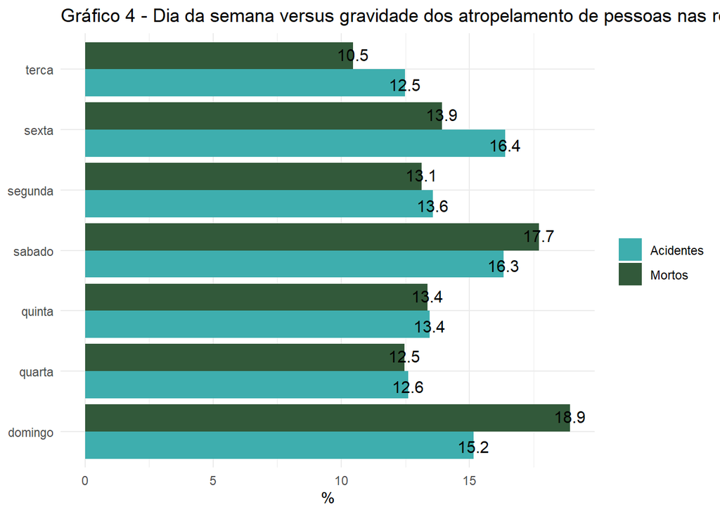

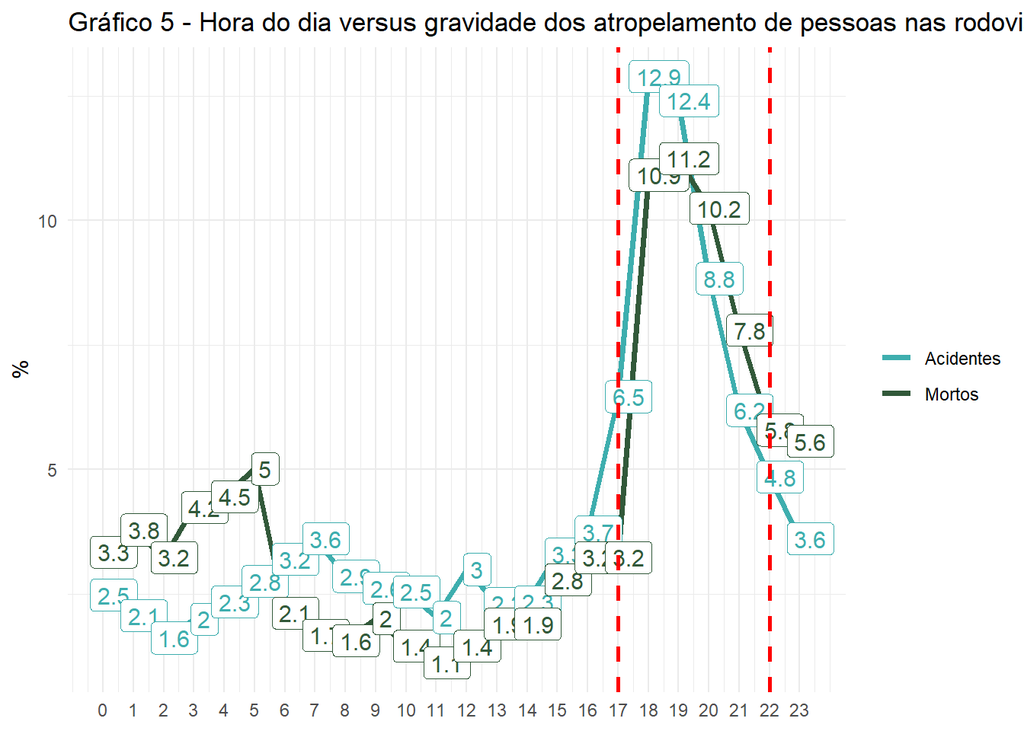

| Classificação do acidente | Qtde. de acidentes | Qtde. de mortos | % Acidentes | % Mortos |
| --- | --- | --- | --- | --- |
| Com vitimas fatais | 885 | 898 | 30.422826 | 100 |
| Com vitimas feridas | 1975 | 0 | 67.892747 | 0 |
| Sem vitimas | 49 | 0 | 1.684428 | 0 |

| Traçado da via | Qtde. de acidentes | Qtde. de mortos | % Acidentes | % Mortos |
| --- | --- | --- | --- | --- |
| Curva | 256 | 72 | 8.8002750 | 8.0178174 |
| Desvio temporario | 79 | 29 | 2.7157099 | 3.2293987 |
| Intersecao de vias | 52 | 7 | 1.7875559 | 0.7795100 |
| Nao informado | 282 | 107 | 9.6940529 | 11.9153675 |
| Ponte | 16 | 8 | 0.5500172 | 0.8908686 |
| Reta | 2181 | 670 | 74.9742179 | 74.6102450 |
| Retorno regulamentado | 12 | 2 | 0.4125129 | 0.2227171 |
| Rotatoria | 15 | 1 | 0.5156411 | 0.1113586 |
| Tunel | 3 | 0 | 0.1031282 | 0.0000000 |
| Viaduto | 13 | 2 | 0.4468890 | 0.2227171 |

| BR da rodovia | Qtde. de acidentes | Qtde. de mortos | % Acidentes | % Mortos |
| --- | --- | --- | --- | --- |
| 101 | 603 | 151 | 20.728773 | 16.815145 |
| 116 | 518 | 178 | 17.806807 | 19.821826 |
| 40 | 184 | 43 | 6.325198 | 4.788419 |
| 381 | 135 | 38 | 4.640770 | 4.231626 |
| 277 | 95 | 29 | 3.265727 | 3.229399 |
| 376 | 83 | 25 | 2.853214 | 2.783964 |
| 364 | 73 | 16 | 2.509453 | 1.781737 |
| 163 | 66 | 16 | 2.268821 | 1.781737 |
| 262 | 60 | 14 | 2.062565 | 1.559020 |
| 316 | 55 | 25 | 1.890684 | 2.783964 |
| 230 | 53 | 22 | 1.821932 | 2.449889 |
| 153 | 51 | 24 | 1.753180 | 2.672606 |
| 232 | 51 | 18 | 1.753180 | 2.004454 |
| 476 | 50 | 9 | 1.718804 | 1.002227 |
| 222 | 46 | 17 | 1.581299 | 1.893096 |

## Estatísticas dos acidentes de trânsito nas rodovias federais (anos)

Estatísticas dos acidentes de trânsito nas rodovias federais (2021, …)

| Item | 2021 |
| --- | --- |
| Total de acidentes | 6.451500e+04 |
| Número de veículos envolvidos | 1.066970e+05 |
| Número de mortes | 5.395000e+03 |
| Mortes/1.000 acidentes | 8.362396e+01 |
| Número de acidentes/morte | 1.195829e+01 |
| Número de feridos | 7.178000e+04 |
| Feridos/1.000 acidentes | 1.112609e+03 |
| Número de acidentes/ferido | 8.987880e-01 |
| Número de ilesos | 6.334400e+04 |
| Ilesos/1.000 acidentes | 9.818492e+02 |
| Número de acidentes/ileso | 1.018486e+00 |